# Reproducible Research: Peer Assessment 1

### Load required libraries/set options

```r
echo = TRUE
options(scipen=1)
library(ggplot2)
library(Hmisc)
```

## Loading and preprocessing the data

##### 1. Load the data/format the variables

```r
if(!file.exists('activity.csv')){
    unzip('activity.zip')
}
raw_actData <- read.csv('activity.csv')
raw_actData$date<-as.Date(raw_actData$date,format="%Y-%m-%d")
actData<-raw_actData[complete.cases(raw_actData),]
```

## What is mean total number of steps taken per day?

The missing values in the data-set are ignored for this part  
##### 1. Calculate the total number of steps taken per day

```r
DailySteps<-aggregate(actData$steps, list(actData$date), sum)
head(DailySteps)
```

```
##      Group.1     x
## 1 2012-10-02   126
## 2 2012-10-03 11352
## 3 2012-10-04 12116
## 4 2012-10-05 13294
## 5 2012-10-06 15420
## 6 2012-10-07 11015
```

##### 2. A histogram of the total number of steps taken each day

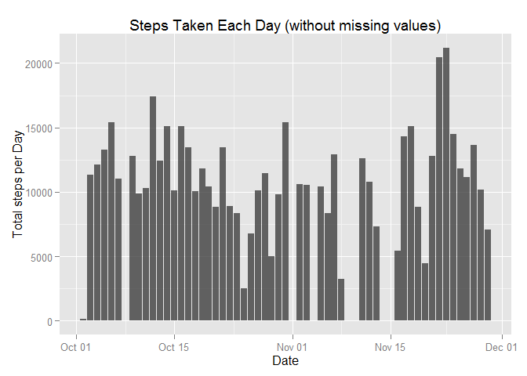

```r
m<-ggplot(data=actData,aes(actData$date,actData$steps))
m+geom_histogram(stat="identity",alpha=0.75)+labs(title = "Steps Taken Each Day (without missing values)", x = "Date", y = "Total steps per Day")
```

##### 3. Calculate and report the mean and median total number of steps taken per day

```r
meanDailySteps<-mean(tapply(actData$steps,actData$date,sum))
medianDailySteps<-median(tapply(actData$steps,actData$date,sum))

meanDailySteps
```

```
## [1] 10766.19
```

```r
medianDailySteps
```

```
## [1] 10765
```

The mean number of Daily Steps is: 10766.1886792  
The median number of Daily Steps is: 10765

## What is the average daily activity pattern?

We average number of steps taken, for each 5 minute interval (across the data-set)

```r
meanStepsPerInterval <- aggregate(actData$steps, by=list(actData$interval), FUN=mean)
names(meanStepsPerInterval)<-c("Interval","MeanSteps")
```

##### 1.Make a time series plot of the 5-minute interval (x-axis) and the average number of steps taken, averaged across all days (y-axis)

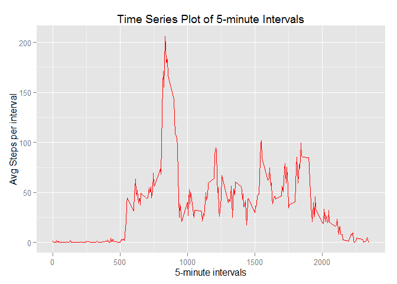

```r
m<-ggplot(data=meanStepsPerInterval,aes(meanStepsPerInterval$Interval,meanStepsPerInterval$MeanSteps))
m+geom_line(color="red")+labs(title = "Time Series Plot of 5-minute Intervals", x = "5-minute intervals", y = "Avg Steps per interval")
```

##### 2. Which 5-minute interval, on average across all the days in the dataset, contains the maximum number of steps?

```r
maxInterval<-meanStepsPerInterval[meanStepsPerInterval$MeanSteps == max(meanStepsPerInterval$MeanSteps),1]
maxSteps<-meanStepsPerInterval[meanStepsPerInterval$MeanSteps == max(meanStepsPerInterval$MeanSteps),2]
```

The interval with most average activity is: 835 with an mean of 206.1698113 steps

## Imputing missing values

##### 1. Calculate and report the total number of missing values in the dataset

```r
NA_count<-length(which(is.na(raw_actData$steps)))
NA_count
```

```
## [1] 2304
```

The total number of rows with missing values is: 2304

##### 2.Devise a strategy for filling in all of the missing values in the dataset.

The impute() function from the Hmisc package was used to fill in the missing values.  
This is invoked with fun=‘mean’ which averages missing values (for the ‘steps’ variable) across the entire data set.  
##### 3.Create a new dataset that is equal to the original dataset but with the missing data filled in.

```r
imputedActData<-raw_actData
imputedActData$steps <- impute(imputedActData$steps, fun=mean)
```

##### 4.Make a histogram of the total number of steps taken each day.

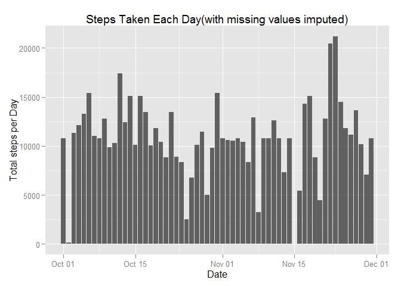

```r
z<-ggplot(data=imputedActData,aes(imputedActData$date,imputedActData$steps))+scale_y_continuous()
z+geom_histogram(stat="identity",alpha=0.75)+labs(title = "Steps Taken Each Day(with missing values imputed)", x = "Date", y = "Total steps per Day")
```

##### Calculate and report the mean and median total number of steps taken per day.

```r
NewMeanDailySteps<-mean(tapply(imputedActData$steps,imputedActData$date,sum))
NewMedianDailySteps<-median(tapply(imputedActData$steps,imputedActData$date,sum))

NewMeanDailySteps
```

```
## [1] 10766.19
```

```r
NewMedianDailySteps
```

```
## [1] 10766.19
```

##### Do these values differ from the estimates from the first part of the assignment?

By excluding missing values, the mean is : 10766.1886792  
By excluding missing values, the median is : 10765

By imputing the missing values, the mean is : 10766.1886792  
By imputing the missing values, the median is: 10766.1886792

##### What is the impact of imputing missing data on the estimates of the total daily number of steps?

The mean remained the same (As the impute was performed using the mean)  
The median value of the ‘imputed’ data increased

## Are there differences in activity patterns between weekdays and weekends?

##### 1. Create a new factor variable in the dataset with two levels - “weekday” and “weekend” indicating whether a given date is a weekday or weekend day.

```r
weekdays1<-c('Monday', 'Tuesday', 'Wednesday', 'Thursday', 'Friday')
imputedActData$DayType<-factor((weekdays(imputedActData$date) %in% weekdays1),levels=c(FALSE,TRUE),labels=c('weekend','weekday'))
```

##### 2. Make a panel plot containing a time series plot

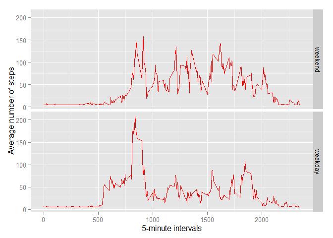

```r
MeanStepsImputedData<-aggregate(imputedActData$steps,list(imputedActData$interval,imputedActData$DayType),mean)

names(MeanStepsImputedData) <-c("interval","DayType","steps")

panel_plot <-ggplot(MeanStepsImputedData, aes(interval, steps))

panel_plot +
  geom_line(color="red") +
  facet_grid(DayType ~ .) +
  xlab("5-minute intervals") +
  ylab("Average number of steps")
```